# SWCtest

Tai McMaaz

April 28, 2015

1<sup>st</sup> = Lebanon 2<sup>nd</sup> = Australia 3<sup>rd</sup> = India

Years 1. 1952 2. 1957 3. 1962 4. 1967 5. 1972 6. 1977 7. 1982 8. 1987 9. 1992 10. 1997 11. 2002 12. 2007

```
##       country continent year lifeExp      pop gdpPercap
## 1 Afghanistan      Asia 1952  28.801  8425333  779.4453
## 2 Afghanistan      Asia 1957  30.332  9240934  820.8530
## 3 Afghanistan      Asia 1962  31.997 10267083  853.1007
## 4 Afghanistan      Asia 1967  34.020 11537966  836.1971
## 5 Afghanistan      Asia 1972  36.088 13079460  739.9811
## 6 Afghanistan      Asia 1977  38.438 14880372  786.1134
```

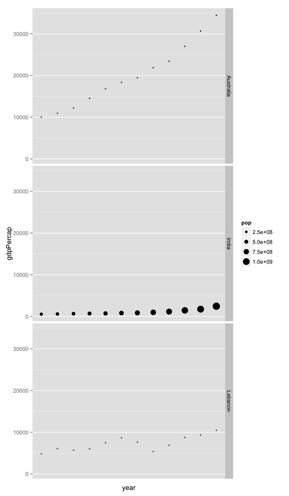

This gapminder data has 1704 rows and 6 columns.  
Shown are trends in GDP per capita for 3 countries: Australia, India, and Lebanon. In Australia, GDP per capita has risen steadily since 1952. However, population is less than 200,000,000. Lebanon also also a low population, though its growth GDP per capita was interrupted by a 15 year civil war. India has grown to a population of over 1 billion, but still the lowest GDP per capita of the three countires.

```
## Source: local data frame [5 x 4]
##
##   continent meanlife minlife maxlife
## 1    Africa 54.80604  39.613  76.442
## 2  Americas 73.60812  60.916  80.653
## 3      Asia 70.72848  43.828  82.603
## 4    Europe 77.64860  71.777  81.757
## 5   Oceania 80.71950  80.204  81.235
```

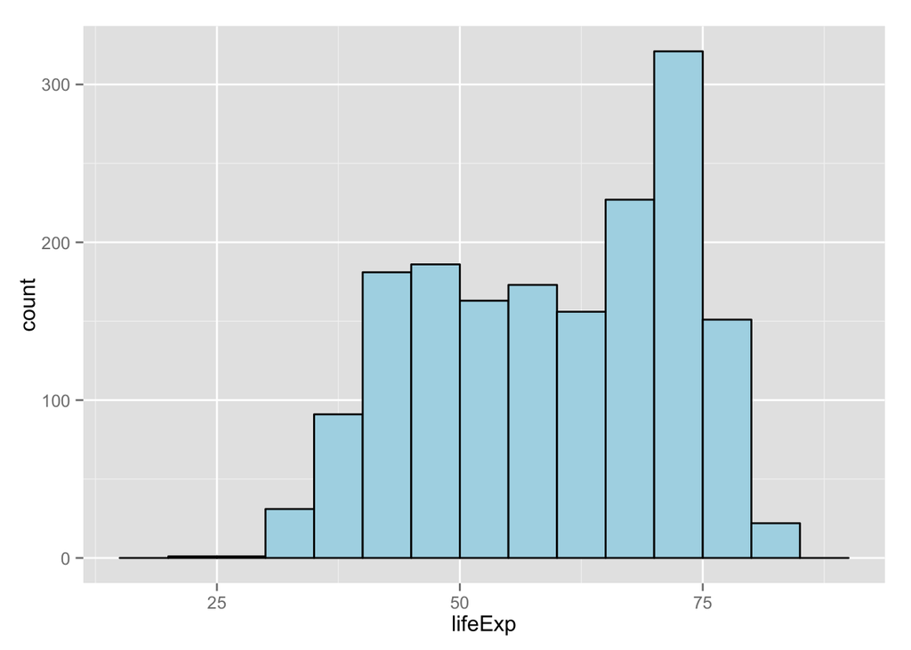

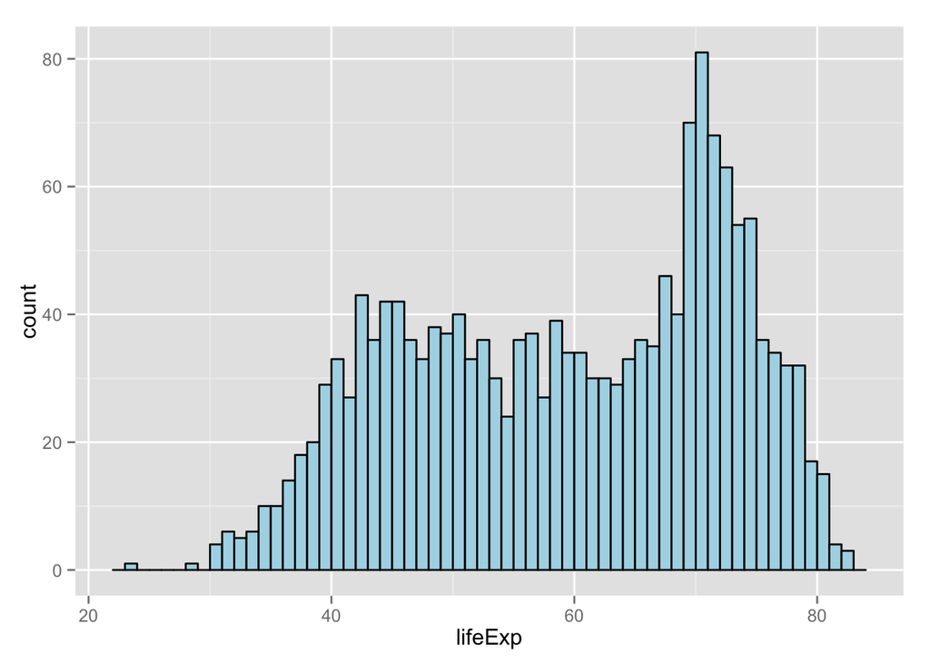